# Writing a reproducible paper with R Markdown and PagedownCorresponding adress: mail@paulcbauer.de, camille.landesvatter@uni-mannheim.de

# Software versioning

Software changes and gets updated, especially with an active developer community like that of R. Luckily you can always access [old versions of R](https://cran.r-project.org/bin/windows/base/old/) and old version of R packages in [the archive](https://cran.r-project.org/src/contrib/Archive/). In the archive you need to choose a particular package, e.g dplyr and search for the right version, e.g., `dplyr_0.2.tar.gz`. Then insert the path in the following function: `install.packages("https://....../dplyr_0.2.tar.gz", repos=NULL, type="source")`. Ideally, however, results will be simply reproducible in the most current R and package versions.

```r
R> cat(paste("#", capture.output(sessionInfo()), "\n", collapse =""))
R>   # or use message() instead of cat()
```

# Data

## Import

Generally, code is evaluated by inserting regular `R Markdown` blocks.

```r
R> x <- 1:10
R> x
```

```
 [1]  1  2  3  4  5  6  7  8  9 10
```

Below we import an exemplary dataset (you can find `data.csv` in the folder with the other files).

```r
R> data <- read.csv("data.csv")
R> head(data)
```

```
  Fertility Agriculture Examination Education Catholic Infant.Mortality
1      80.2        17.0          15        12     9.96             22.2
2      83.1        45.1           6         9    84.84             22.2
3      92.5        39.7           5         5    93.40             20.2
4      85.8        36.5          12         7    33.77             20.3
5      76.9        43.5          17        15     5.16             20.6
6      76.1        35.3           9         7    90.57             26.6
```

## Putting your entire data into the .rmd file

Applying the function `dput()` to an object gives you the code needed to reproduce that object. So you could paste that code into your `.rmd` file if you don’t want to have extra data files. This makes sense were data files are small.

```r
R> dput(data[1:5,]) # here we only take a subset
```

```
structure(list(Fertility = c(80.2, 83.1, 92.5, 85.8, 76.9), Agriculture = c(17,
45.1, 39.7, 36.5, 43.5), Examination = c(15L, 6L, 5L, 12L, 17L
), Education = c(12L, 9L, 5L, 7L, 15L), Catholic = c(9.96, 84.84,
93.4, 33.77, 5.16), Infant.Mortality = c(22.2, 22.2, 20.2, 20.3,
20.6)), row.names = c(NA, 5L), class = "data.frame")
```

You can then insert the dput output in your `.rmd` as below.

```r
R> data <- structure(list(Fertility = c(80.2, 83.1, 92.5, 85.8, 76.9), Agriculture = c(17,
R+ 45.1, 39.7, 36.5, 43.5), Examination = c(15L, 6L, 5L, 12L, 17L
R+ ), Education = c(12L, 9L, 5L, 7L, 15L), Catholic = c(9.96, 84.84,
R+ 93.4, 33.77, 5.16), Infant.Mortality = c(22.2, 22.2, 20.2, 20.3,
R+ 20.6)), class = "data.frame", row.names = c(NA, -5L))
```

# Tables

Producing good tables and referencing these tables within a R Markdown document has been a hassle but got much better. Examples that you may use are shown below.

## Tables with kable() and kable_styling()

A great function is `kable()` (`knitr` package) in combination with `kableExtra`. Table 1 provides an example. To reference the table produced by the chunk you need to add ´tab:´ to the chunk name, i.e., ´tab:table-2´ and would reference it by adding “`Table \@ref(tab:table-2)`” in your text.

```r
R> library(knitr)
R> library(kableExtra)
R>
R> kable(swiss[1:10,], row.names = TRUE,
R+       caption = 'Table with kable() and kablestyling()',
R+       format = "html", booktabs = T) %>%
R+         kable_styling(full_width = T,
R+                       latex_options = c("striped",
R+                                         "scale_down",
R+                                         "HOLD_position"),
R+                       font_size = 10)
```

Table 1: Table with kable() and kablestyling()

|  | Fertility | Agriculture | Examination | Education | Catholic | Infant.Mortality |
| --- | --- | --- | --- | --- | --- | --- |
| Courtelary | 80.2 | 17.0 | 15 | 12 | 9.96 | 22.2 |
| Delemont | 83.1 | 45.1 | 6 | 9 | 84.84 | 22.2 |
| Franches-Mnt | 92.5 | 39.7 | 5 | 5 | 93.40 | 20.2 |
| Moutier | 85.8 | 36.5 | 12 | 7 | 33.77 | 20.3 |
| Neuveville | 76.9 | 43.5 | 17 | 15 | 5.16 | 20.6 |
| Porrentruy | 76.1 | 35.3 | 9 | 7 | 90.57 | 26.6 |
| Broye | 83.8 | 70.2 | 16 | 7 | 92.85 | 23.6 |
| Glane | 92.4 | 67.8 | 14 | 8 | 97.16 | 24.9 |
| Gruyere | 82.4 | 53.3 | 12 | 7 | 97.67 | 21.0 |
| Sarine | 82.9 | 45.2 | 16 | 13 | 91.38 | 24.4 |

## Tables with modelsummary

The `modelsummary` package provides a variety of tables and plots to summarize statistical models and data in R. Modellsummary plots and tables are highly customizable and they can be saved to almost all formats, e.g., HTML, PDF and Markdown. This makes ist especially easy to embed them in dynamic documents. Please look at the package’s extensive [documentation](https://vincentarelbundock.github.io/modelsummary/index.html) where they also show examples for almost any plot or table you might be looking for. In this template we demonstrate an example for modelsummary’s `datasummary` function. `Datasummary` creates frequency tables, crosstab tables, correlation tables, balance tables and many **more**.

### Summarize numeric variables

```r
R> library(modelsummary)
R> datasummary_skim(swiss,
R+                  type="numeric",
R+                  histogram=T,
R+                  title = "Summary: Numeric variables")
```

Unique

Missing Pct.

Mean

SD

Min

Median

Max

Histogram

Fertility

46

0

70.1

12.5

35.0

70.4

92.5

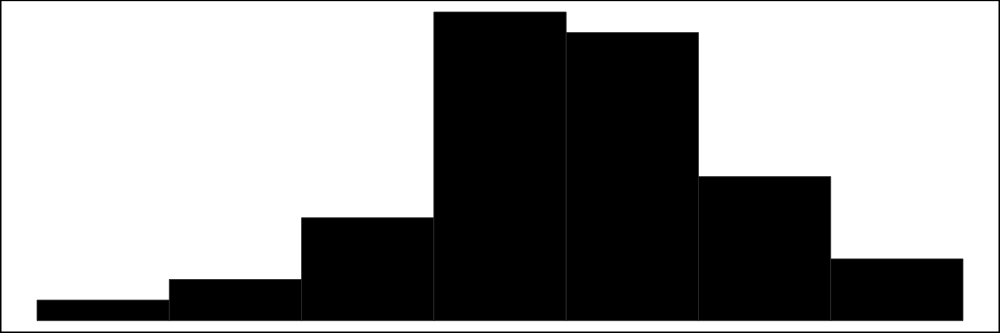

Agriculture

47

0

50.7

22.7

1.2

54.1

89.7

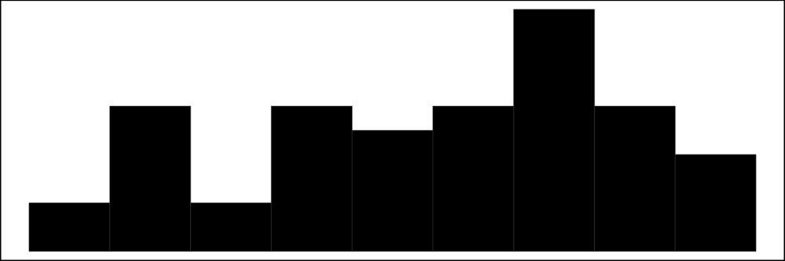

Examination

22

0

16.5

8.0

3.0

16.0

37.0

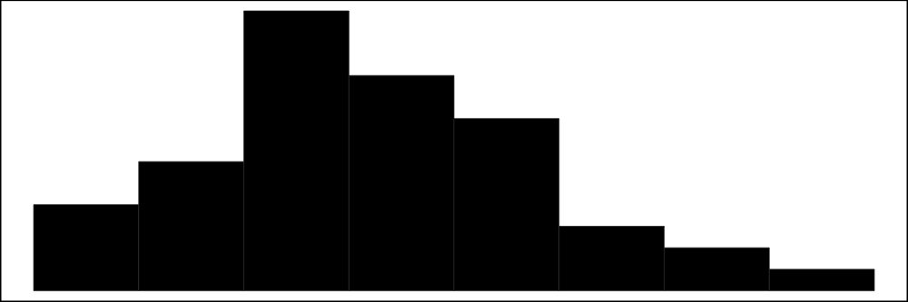

Education

19

0

11.0

9.6

1.0

8.0

53.0

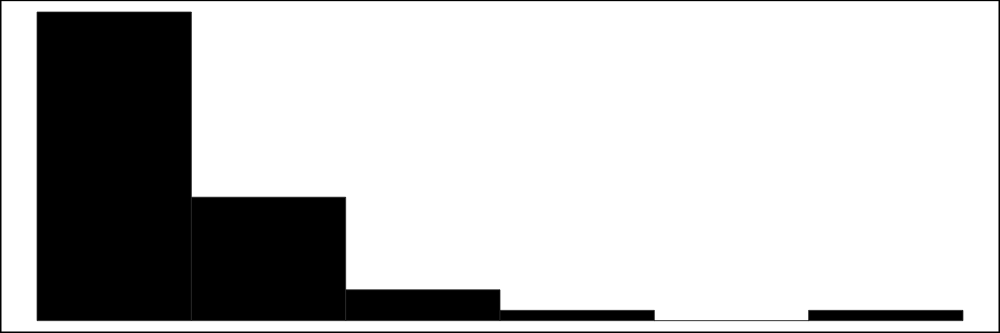

Catholic

46

0

41.1

41.7

2.1

15.1

100.0

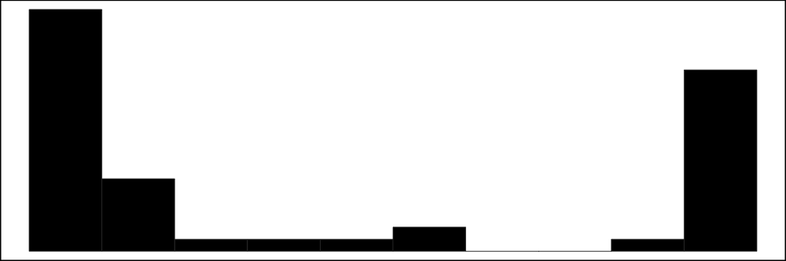

Infant.Mortality

37

0

19.9

2.9

10.8

20.0

26.6

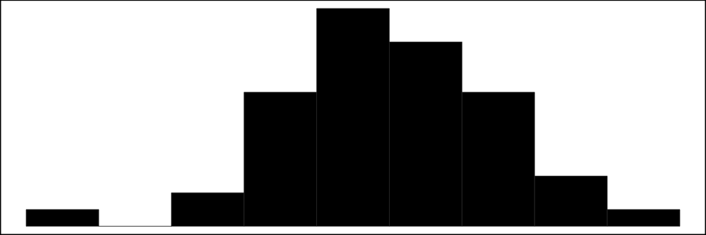